# Regresión Lineal desde Cero

# 8 Verificación con `lm()`

Finalmente, verifiquemos que nuestros cálculos manuales coinciden con la función `lm()` de R:

```r
modelo <- lm(salario ~ educ + exper, data = datos)
summary(modelo)
```

```
##
## Call:
## lm(formula = salario ~ educ + exper, data = datos)
##
## Residuals:
##    Min     1Q Median     3Q    Max
## -9.051 -1.681  0.472  1.887  4.460
##
## Coefficients:
##             Estimate Std. Error t value Pr(>|t|)
## (Intercept)  4.84344    1.46212   3.313  0.00178 **
## educ         2.49510    0.08287  30.110  < 2e-16 ***
## exper        1.23962    0.04720  26.266  < 2e-16 ***
## ---
## Signif. codes:  0 '***' 0.001 '**' 0.01 '*' 0.05 '.' 0.1 ' ' 1
##
## Residual standard error: 2.812 on 47 degrees of freedom
## Multiple R-squared:  0.973,  Adjusted R-squared:  0.9718
## F-statistic: 846.3 on 2 and 47 DF,  p-value: < 2.2e-16
```

## 8.1 Comparación directa

```r
comp <- data.frame(
  Parametro = c("β̂₀", "β̂₁", "β̂₂", "σ̂²", "R²"),
  Manual = round(c(beta_hat[1], beta_hat[2], beta_hat[3], sigma2_hat, R2), 6),
  lm     = round(c(coef(modelo)[1], coef(modelo)[2], coef(modelo)[3],
                    summary(modelo)$sigma^2, summary(modelo)$r.squared), 6)
)

kable(comp, col.names = c("Parámetro", "Cálculo manual", "lm()"),
      align = "lcc") %>%
  kable_styling(bootstrap_options = c("striped", "hover"), full_width = FALSE)
```

| Parámetro | Cálculo manual | lm() |
| --- | --- | --- |
| β̂₀ | 4.843435 | 4.843435 |
| β̂₁ | 2.495096 | 2.495096 |
| β̂₂ | 1.239624 | 1.239624 |
| σ̂² | 7.909370 | 7.909370 |
| R² | 0.972983 | 0.972983 |

# 9 Prueba de una restricción lineal adicional

## 9.1 ¿El efecto de la educación es el doble que el de la experiencia?

Podemos plantear la hipótesis: $H_0: \beta_1 = 2\beta_2$, equivalentemente $\beta_1 - 2\beta_2 = 0$.

$$\mathbf{R} = \begin{pmatrix} 0 & 1
& -2 \end{pmatrix}, \qquad r = 0$$

$$t =
\frac{\mathbf{R}\hat{\boldsymbol{\beta}} - r}{\sqrt{\hat{\sigma}^2
\mathbf{R}(\mathbf{X}'\mathbf{X})^{-1}\mathbf{R}'}} \sim
t_{n-(K+1)}$$

```r
R_rest <- matrix(c(0, 1, -2), nrow = 1)
r_rest <- 0

Rb <- R_rest %*% beta_hat - r_rest
se_Rb <- sqrt(as.numeric(sigma2_hat * R_rest %*% XtX_inv %*% t(R_rest)))
t_rest <- as.numeric(Rb) / se_Rb
p_rest <- 2 * pt(abs(t_rest), df = gl, lower.tail = FALSE)

cat("β̂₁ - 2β̂₂ =", round(as.numeric(Rb), 4), "\n")
```

```
## β̂₁ - 2β̂₂ = 0.0158
```

```r
cat("Error estándar:", round(se_Rb, 4), "\n")
```

```
## Error estándar: 0.1291
```

```r
cat("t =", round(t_rest, 4), "\n")
```

```
## t = 0.1227
```

```r
cat("p-valor =", round(p_rest, 4), "\n")
```

```
## p-valor = 0.9028
```

```r
if (p_rest < 0.05) {
  cat("\n→ Rechazamos H₀: la educación NO tiene exactamente el doble de efecto que la experiencia.\n")
} else {
  cat("\n→ No rechazamos H₀: no hay evidencia suficiente contra la hipótesis.\n")
}
```

```
##
## → No rechazamos H₀: no hay evidencia suficiente contra la hipótesis.
```

# 10 Visualización de resultados

## 10.1 Valores observados vs. ajustados

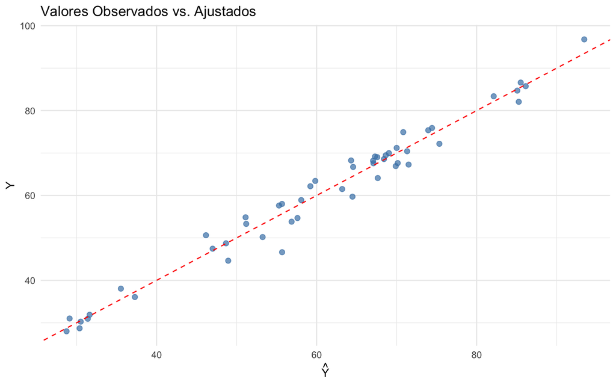

```r
datos$salario_hat <- as.numeric(Y_hat)

ggplot(datos, aes(x = salario_hat, y = salario)) +
  geom_point(color = "steelblue", size = 2, alpha = 0.7) +
  geom_abline(intercept = 0, slope = 1, linetype = "dashed", color = "red") +
  labs(title = "Valores Observados vs. Ajustados",
       x = expression(hat(Y)), y = "Y") +
  theme_minimal()
```

## 10.2 Residuales vs. valores ajustados

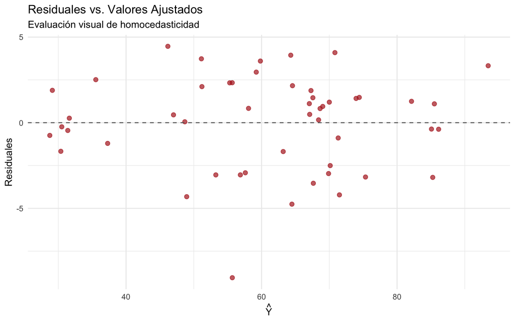

```r
datos$residuales <- as.numeric(e)

ggplot(datos, aes(x = salario_hat, y = residuales)) +
  geom_point(color = "firebrick", size = 2, alpha = 0.7) +
  geom_hline(yintercept = 0, linetype = "dashed", color = "grey40") +
  labs(title = "Residuales vs. Valores Ajustados",
       subtitle = "Evaluación visual de homocedasticidad",
       x = expression(hat(Y)), y = "Residuales") +
  theme_minimal()
```

## 10.3 Histograma de residuales

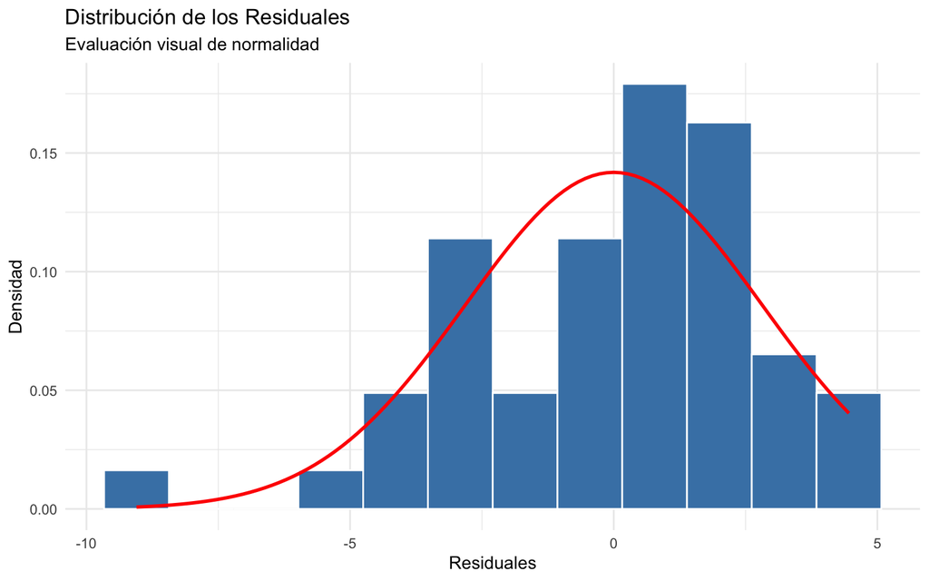

```r
ggplot(datos, aes(x = residuales)) +
  geom_histogram(aes(y = after_stat(density)),
                 fill = "steelblue", color = "white", bins = 12) +
  stat_function(fun = dnorm,
                args = list(mean = 0, sd = sqrt(sigma2_hat)),
                color = "red", linewidth = 1) +
  labs(title = "Distribución de los Residuales",
       subtitle = "Evaluación visual de normalidad",
       x = "Residuales", y = "Densidad") +
  theme_minimal()
```

# 11 Resumen de fórmulas clave

| Concepto | Fórmula |
| --- | --- |
| Estimador MCO | $\hat{\boldsymbol{\beta}} = (\mathbf{X}'\mathbf{X})^{-1}\mathbf{X}'\mathbf{Y}$ |
| Residuales | $\mathbf{e} = \mathbf{Y} - \mathbf{X}\hat{\boldsymbol{\beta}}$ |
| Varianza estimada | $\hat{\sigma}^2 = \frac{\mathbf{e}'\mathbf{e}}{n-(K+1)}$ |
| Distribución de $\hat{\beta}$ | $\hat{\boldsymbol{\beta}} \sim N(\boldsymbol{\beta}, \hat{\sigma}^2(\mathbf{X}'\mathbf{X})^{-1})$ |
| Prueba $t$ individual | $t = \frac{\hat{\beta}_k}{\sqrt{\hat{\sigma}^2(\mathbf{X}'\mathbf{X})^{-1}_{kk}}} \sim t_{n-(K+1)}$ |
| Prueba $F$ global | $F = \frac{SST_R/K}{SSE/(n-K-1)} \sim F_{K, n-K-1}$ |
| $R^2$ | $R^2 = 1 - \frac{SSE}{SST_{OT}}$ |
| Restricción lineal | $t = \frac{\mathbf{R}\hat{\boldsymbol{\beta}} - r}{\sqrt{\hat{\sigma}^2 \mathbf{R}(\mathbf{X}'\mathbf{X})^{-1}\mathbf{R}'}} \sim t_{n-(K+1)}$ |

# 12 Tarea

1. **Cambia la semilla** (`set.seed`) y vuelve a correr todo el documento. ¿Cómo cambian los estimadores? ¿Y el $R^2$?
2. **Aumenta $\sigma$** a 10 y repite. ¿Qué pasa con la significancia de los coeficientes y el $R^2$?
3. **Agrega una variable irrelevante**: genera una variable aleatoria sin relación con $Y$ (por ejemplo, `z <- rnorm(n)`) y agrégala al modelo. ¿Es significativa? ¿Qué pasa con el $R^2$ y el $R^2$ ajustado?
4. **Prueba la restricción** $H_0: \beta_1 + \beta_2 = 3.7$ usando la estadística $t$ con $\mathbf{R} = (0, 1, 1)$ y $r = 3.7$.

**Entrega el 7 de junio de 2026**